# Web Scraping

2022-10-24

## Motivation

For homework we need to know who are the candidates

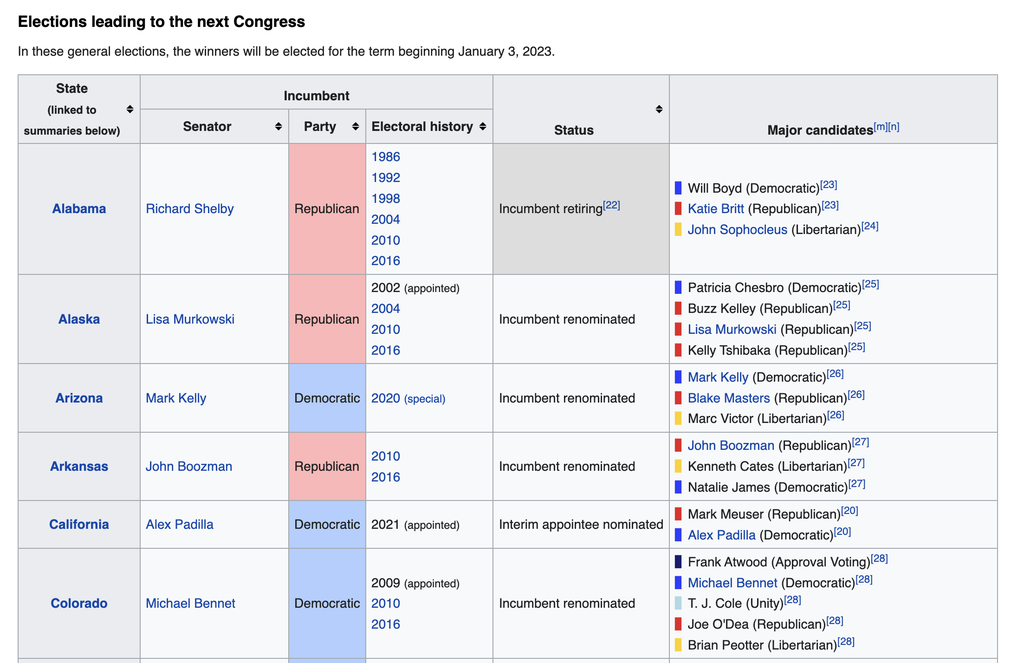

## Motivation

```r
library(rvest)
```

```r
url <- "https://en.wikipedia.org/w/index.php?title=2022_United_States_Senate_elections&oldid=1117602481"
h <- read_html(url)
tabs <- h |> html_nodes("table")
tab <- tabs[[13]] |> html_table()
names(tab) <- c("State", "Senator", "Party", "History", "Status", "Candidates")
```

## Motivation

```r
head(select(tab[-1,], State, Senator, Party, Candidates))
```

```
#> # A tibble: 6 × 4
#>   State      Senator        Party      Candidates
#>   <chr>      <chr>          <chr>      <chr>
#> 1 Alabama    Richard Shelby Republican "▌Will Boyd (Democratic)[23]\n▌Katie Bri…
#> 2 Alaska     Lisa Murkowski Republican "▌Patricia Chesbro (Democratic)[25]\n▌Bu…
#> 3 Arizona    Mark Kelly     Democratic "▌Mark Kelly (Democratic)[26]\n▌Blake Ma…
#> 4 Arkansas   John Boozman   Republican "▌John Boozman (Republican)[27]\n▌Kennet…
#> 5 California Alex Padilla   Democratic "▌Mark Meuser (Republican)[20]\n▌Alex Pa…
#> 6 Colorado   Michael Bennet Democratic "▌Frank Atwood (Approval Voting)[28]\n▌M…
```

## Motivation

```r
cat(tab$Candidates[2])
```

```
#> ▌Will Boyd (Democratic)[23]
#> ▌Katie Britt (Republican)[23]
#> ▌John Sophocleus (Libertarian)[24]
```

## Web scraping

- The data we need to answer a question is not always in a spreadsheet ready for us to read.
- For example, the US murders dataset we used in the R Basics chapter originally comes from this Wikipedia page:

```r
url <- paste0("https://en.wikipedia.org/w/index.php?title=",
              "Gun_violence_in_the_United_States_by_state",
              "&direction=prev&oldid=810166167")
```

## Web scraping

- You can see the data table when you visit the webpage:

[figure not shown]

## Web scraping

- Unfortunately, there is no link to a data file.
- To make the data frame that is loaded when we type `data(murders)`, we had to do some *web scraping*.
- *Web scraping*, or *web harvesting*, is the term we use to describe the process of extracting data from a website.
- The reason we can do this is because the information used by a browser to render webpages is received as a text file from a server.

## Web scraping

- The text is code written in hyper text markup language (HTML).
- Every browser has a way to show the html source code for a page, each one different.
- On Chrome, you can use Control-U on a PC and command+alt+U on a Mac.

## Web scraping

- You will see something like this:

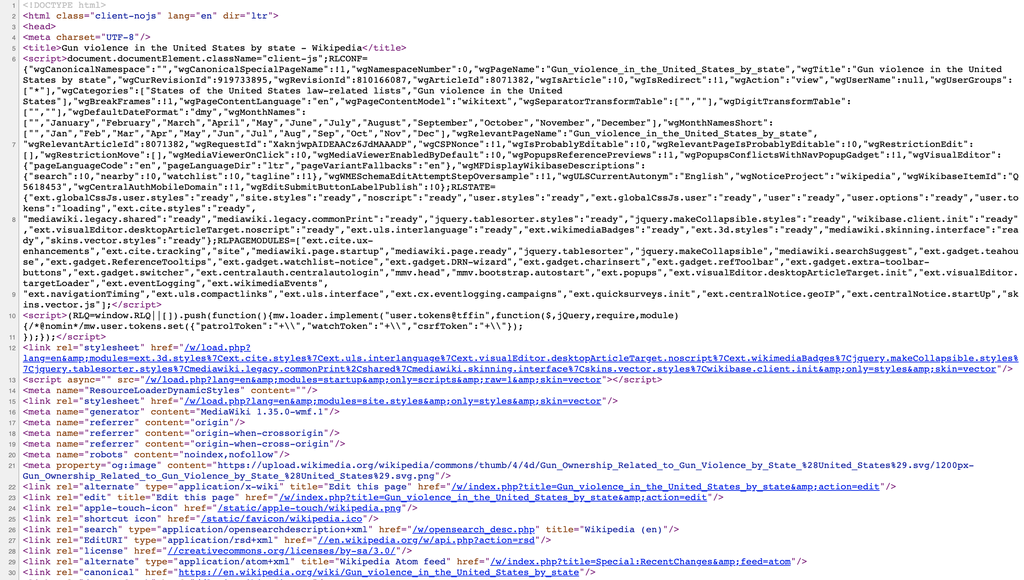

## HTML

- Because this code is accessible, we can download the HTML file, import it into R, and then write programs to extract the information we need from the page.
- However, once we look at HTML code, this might seem like a daunting task.
- But we will show you some convenient tools to facilitate the process.
- To get an idea of how it works, here are a few lines of code from the Wikipedia page that provides the US murders data:

## HTML

```
<table class="wikitable sortable">
<tr>
<th>State</th>
<th><a href="/wiki/List_of_U.S._states_and_territories_by_population"
title="List of U.S. states and territories by population">Population</a><br />
<small>(total inhabitants)</small><br />
<small>(2015)</small> <sup id="cite_ref-1" class="reference">
<a href="#cite_note-1">[1]</a></sup></th>
<th>Murders and Nonnegligent
<p>Manslaughter<br />
<small>(total deaths)</small><br />
<small>(2015)</small> <sup id="cite_ref-2" class="reference">
<a href="#cite_note-2">[2]</a></sup></p>
</th>
<th>Murder and Nonnegligent
<p>Manslaughter Rate<br />
<small>(per 100,000 inhabitants)</small><br />
<small>(2015)</small></p>
</th>
</tr>
```

## HTML

```
<tr>
<td><a href="/wiki/Alabama" title="Alabama">Alabama</a></td>
<td>4,853,875</td>
<td>348</td>
<td>7.2</td>
</tr>
<tr>
<td><a href="/wiki/Alaska" title="Alaska">Alaska</a></td>
<td>737,709</td>
<td>59</td>
<td>8.0</td>
</tr>
<tr>
```

## The rvest package

- The **tidyverse** provides a web harvesting package called **rvest**.
- The first step using this package is to import the webpage into R.
- The package makes this quite simple:

```r
library(tidyverse)
library(rvest)
h <- read_html(url)
```

- Note that the entire Murders in the US Wikipedia webpage is now contained in `h`.

## The rvest package

- The class of this object is:

```r
class(h)
```

```
#> [1] "xml_document" "xml_node"
```

## The rvest package

- The **rvest** package is actually more general; it handles XML documents.
- XML is a general markup language (that’s what the ML stands for) that can be used to represent any kind of data.
- HTML is a specific type of XML specifically developed for representing webpages.
- Here we focus on HTML documents.

## The rvest package

- Now, how do we extract the table from the object `h`? If we print `h`, we don’t really see much:

```r
h
```

```
#> {html_document}
#> <html class="client-nojs" lang="en" dir="ltr">
#> [1] <head>\n<meta http-equiv="Content-Type" content="text/html; charset=UTF-8 ...
#> [2] <body class="skin-vector-legacy mediawiki ltr sitedir-ltr mw-hide-empty-e ...
```

## The rvest package

- We can see all the code that defines the downloaded webpage using the `html_text` function like this:

```r
html_text(h)
```

## The rvest package

- We don’t show the output here because it includes thousands of characters, but if we look at it, we can see the data we are after are stored in an HTML table: you can see this in this line of the HTML code above `<table class="wikitable sortable">`.
- The different parts of an HTML document, often defined with a message in between `<` and `>` are referred to as *nodes*.
- The **rvest** package includes functions to extract nodes of an HTML document: `html_nodes` extracts all nodes of different types and `html_node` extracts the first one.
- To extract the tables from the html code we use:

## The rvest package

```r
tab <- h |> html_nodes("table")
```

- Now, instead of the entire webpage, we just have the html code for the tables in the page:

```r
tab
```

```
#> {xml_nodeset (2)}
#> [1] <table class="wikitable sortable"><tbody>\n<tr>\n<th>State\n</th>\n<th>\n ...
#> [2] <table class="nowraplinks hlist mw-collapsible mw-collapsed navbox-inner" ...
```

- The table we are interested is the first one:

```r
tab[[1]]
```

```
#> {html_node}
#> <table class="wikitable sortable">
#> [1] <tbody>\n<tr>\n<th>State\n</th>\n<th>\n<a href="/wiki/List_of_U.S._states ...
```

## The rvest package

- This is clearly not a tidy dataset, not even a data frame.
- In the code above, you can definitely see a pattern and writing code to extract just the data is very doable.
- In fact, **rvest** includes a function just for converting HTML tables into data frames:

## The rvest package

```r
tab <- tab[[1]] |> html_table()
class(tab)
```

```
#> [1] "tbl_df"     "tbl"        "data.frame"
```

- We are now much closer to having a usable data table:

```r
tab <- tab |> setNames(c("state", "population", "total", "murder_rate"))
head(tab)
```

```
#> # A tibble: 6 × 4
#>   state      population total murder_rate
#>   <chr>      <chr>      <chr>       <dbl>
#> 1 Alabama    4,853,875  348           7.2
#> 2 Alaska     737,709    59            8
#> 3 Arizona    6,817,565  309           4.5
#> 4 Arkansas   2,977,853  181           6.1
#> 5 California 38,993,940 1,861         4.8
#> 6 Colorado   5,448,819  176           3.2
```

## The rvest package

- We still have some wrangling to do.
- For example, we need to remove the commas and turn characters into numbers.
- Before continuing with this, we will learn a more general approach to extracting information from web sites.

## CSS selectors

- The default look of a webpage made with the most basic HTML is quite unattractive.
- The aesthetically pleasing pages we see today are made using CSS to define the look and style of webpages.
- The fact that all pages for a company have the same style usually results from their use of the same CSS file to define the style.
- The general way these CSS files work is by defining how each of the elements of a webpage will look.
- The title, headings, itemized lists, tables, and links, for example, each receive their own style including font, color, size, and distance from the margin.

## CSS selectors

- CSS does this by leveraging patterns used to define these elements, referred to as *selectors*.
- An example of such a pattern, which we used above, is `table`, but there are many, many more.
- If we want to grab data from a webpage and we happen to know a selector that is unique to the part of the page containing this data, we can use the `html_nodes` function.
- However, knowing which selector can be quite complicated.
- In fact, the complexity of webpages has been increasing as they become more sophisticated.
- For some of the more advanced ones, it seems almost impossible to find the nodes that define a particular piece of data.

## CSS selectors

- However, selector gadgets actually make this possible.
- SelectorGadget[^5] is piece of software that allows you to interactively determine what CSS selector you need to extract specific components from the webpage.
- If you plan on scraping data other than tables from html pages, we highly recommend you install it.
- A Chrome extension is available which permits you to turn on the gadget and then, as you click through the page, it highlights parts and shows you the selector you need to extract these parts.

## JSON

- Sharing data on the internet has become more and more common.
- Unfortunately, providers use different formats, which makes it harder for data scientists to wrangle data into R.
- Yet there are some standards that are also becoming more common.
- Currently, a format that is widely being adopted is the JavaScript Object Notation or JSON.
- Because this format is very general, it is nothing like a spreadsheet.
- This JSON file looks more like the code you use to define a list.

## JSON

- Here is an example of information stored in a JSON format:

```
#>
#> [
#>   {
#>     "name": "Miguel",
#>     "student_id": 1,
#>     "exam_1": 85,
#>     "exam_2": 86
#>   },
#>   {
#>     "name": "Sofia",
#>     "student_id": 2,
#>     "exam_1": 94,
#>     "exam_2": 93
#>   },
#>   {
#>     "name": "Aya",
#>     "student_id": 3,
#>     "exam_1": 87,
#>     "exam_2": 88
#>   },
#>   {
#>     "name": "Cheng",
#>     "student_id": 4,
#>     "exam_1": 90,
#>     "exam_2": 91
#>   }
#> ]
```

## JSON

- The file above actually represents a data frame.
- To read it, we can use the function `fromJSON` from the **jsonlite** package.
- Note that JSON files are often made available via the internet.
- Several organizations provide a JSON API or a web service that you can connect directly to and obtain data.

## JSON

- Here is an example providing information Nobel prize winners:

```r
nobel <- fromJSON("http://api.nobelprize.org/v1/prize.json")
```

- This downloads a list.

## JSON

- The first argument is a table with information about Nobel prize winners:

```r
filter(nobel$prize, category == "literature" & year == "1971") |> pull(laureates)
```

```
#> [[1]]
#>    id firstname surname
#> 1 645     Pablo  Neruda
#>                                                                                                motivation
#> 1 "for a poetry that with the action of an elemental force brings alive a continent's destiny and dreams"
#>   share
#> 1     1
```

## JSON

- You can learn much more by examining tutorials and help files from the **jsonlite** package.
- This package is intended for relatively simple tasks such as converting data into tables.
- For more flexibility, we recommend `rjson`.